# Data exploration

## Introduction

### Today’s objectives

## Setting up the exercise

We start by importing libraries and the dataset.

```python
# Load libraries
import pandas as pd # Import pandas
import matplotlib.pyplot as plt # Import the pyplot module from matplotlib
import seaborn as sns # Import seaborn

# Import the dataset specifying which Excel sheet name to load the data from
df = pd.read_excel('../Data/Smith_glass_post_NYT_data.xlsx', sheet_name='Supp_traces')
```

As in the previous class, we load the dataset using **Pandas**. The dataset comes from Smith, Isaia, and Pearce (2011) and contains the chemical concentrations in volcanic tephra belonging to the recent activity (last 15 ky) of the Campi Flergrei Caldera (Italy). The dataset is contained in an Excel file that contains two sheets named `'Supp_majors'` and `'Supp_traces'`. In Listing 1, we use the `sheet_name` argument to the `read_excel()` ([doc](https://pandas.pydata.org/docs/reference/api/pandas.read_excel.html)) function to specify that we want to load the sheet containing trace elements.

**Good reference book**

The use of this dataset is inspired by the by the book *Introduction to Python in Earth Science Data Analysis: From Descriptive Statistics to Machine Learning* by Petrelli (2021).

### Basics of plotting in Python

Listing 1 also loads two libraries for plotting:

- [**Matplotlib**](https://matplotlib.org/stable/users/explain/quick_start.html) is the library for plotting in Python. It allows for the finest and most comprehensive level of customisation, but it take some time to get used to. You can visit the [gallery](https://matplotlib.org/stable/gallery/index.html) to get some inspiration.
- [**Seaborn**](https://seaborn.pydata.org/tutorial/introduction) is built on Matplotlib, but provides some higher-level functions to easily produce stats-oriented plots. It looks good by default, but finer customisation might be difficult and might result to using Matplotlib. Again, check out the [gallery](https://seaborn.pydata.org/examples/index.html).

Here again, the idea is not to make you expert in *Matplotlib* or *Seaborn*, but rather to provide you with the minimum knowledge for you to further explore this tools in the context of your research.

#### Components of a Figure

Let’s start to look at the basic components of a *Matplotlib* figure. There are two “hosts” to any plot (Figure 1):

1. A **Figure** represents the main canevas;
2. **Axes** are contained within the figure and is where most of the plotting will occur.

The easiest way to define a figure is using the `subplots()` function (Listing 2). Note that the code returns two variables - `fig` and `ax` - which are the figure and the axes, respectively.

Listing 2: Define a figure and one axes.

```python
import matplotlib.pyplot as plt
fig, ax = plt.subplots()
```

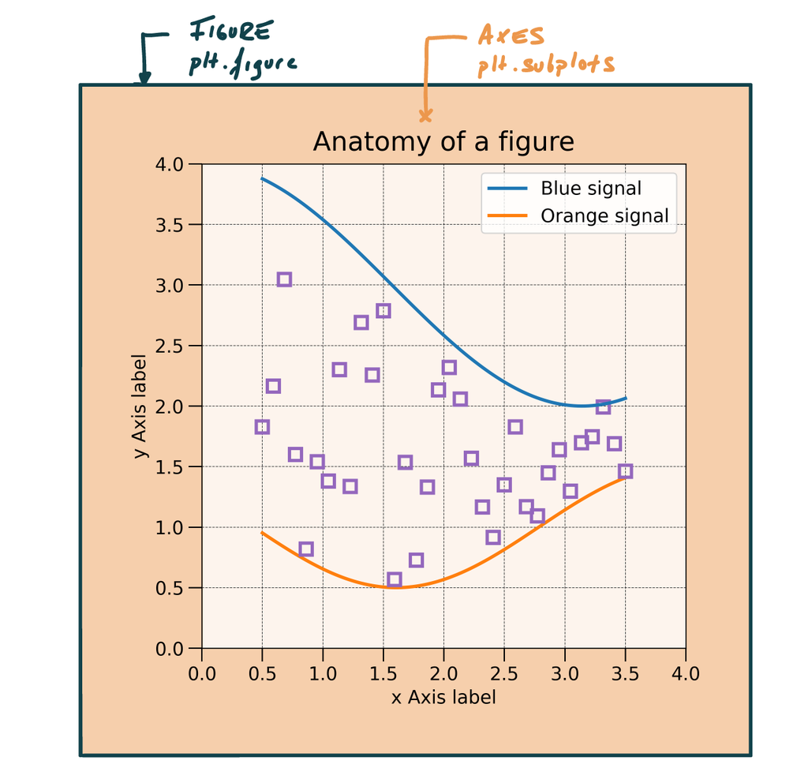

Figure 1: Main figure and axes of a *Matplotlib* figure

Most additional components of a plot are controlled via the `ax` variable, which can be used to (Figure 2):

- *Plot* (e.g., line plot or scatter plots)
- *Set labels* (e.g., x-label, y-label, title)
- Add various *components* (e.g., legend, grid)

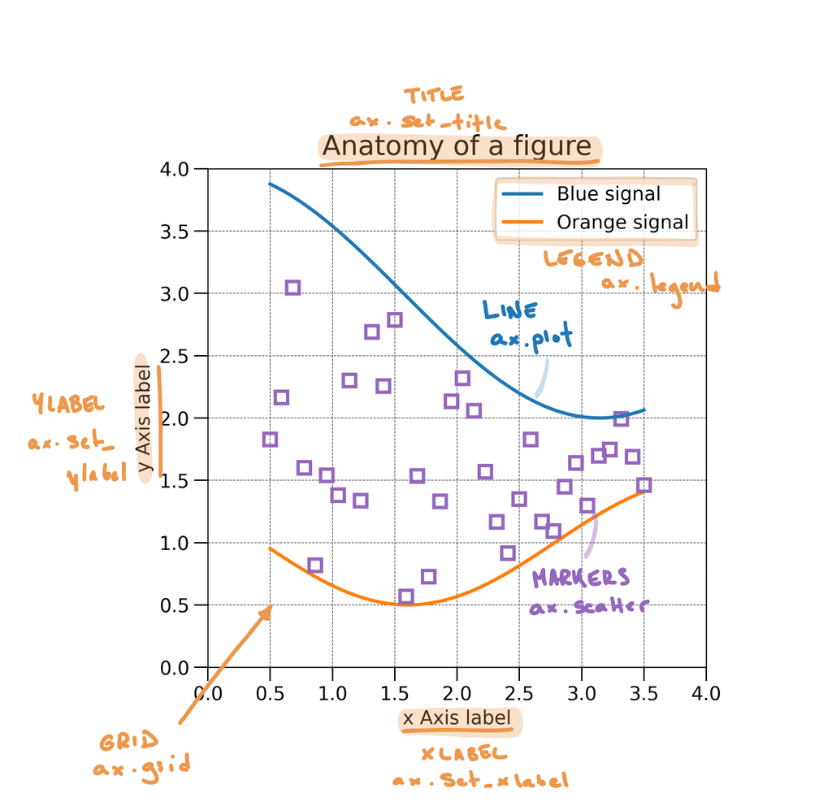

Figure 2: Basic components of a *Matplotlib* figure

**Plotting exercise**

Listing 3 defines a figure and plots some data. Table 1 and Figure 2 illustrate some of the most frequently used functions for customising plots.

Use these functions to customise Listing 3. Some hints:

- Remember that a *function* takes some *arguments* provided between *parentheses* (e.g., `ax.title(argument)`). Each function might accept different types of arguments.
- Titles and labels require a *string*, so remember to use `" "` or `' '`.
- For now, the legend does not require any argument, so you can leave the parentheses empty.
- Setting the grid requires one argument: do we want to show the grid (`True`) or not (`False`)

Table 1: Some of the most frequently used plotting functions.

| Function | Description | Argument Type | Example Argument |
| --- | --- | --- | --- |
| [`ax.set_title`](https://matplotlib.org/stable/api/_as_gen/matplotlib.axes.Axes.set_title.html) | Sets the title of the axes | str | “My Plot Title” |
| [`ax.set_xlabel`](https://matplotlib.org/stable/api/_as_gen/matplotlib.axes.Axes.set_xlabel.html) | Sets the label for the x-axis | str | “X Axis Label” |
| [`ax.set_ylabel`](https://matplotlib.org/stable/api/_as_gen/matplotlib.axes.Axes.set_ylabel.html) | Sets the label for the y-axis | str | “Y Axis Label” |
| [`ax.legend`](https://matplotlib.org/stable/api/_as_gen/matplotlib.axes.Axes.legend.html) | Displays the legend | None | None (default) |
| [`ax.grid`](https://matplotlib.org/stable/api/_as_gen/matplotlib.axes.Axes.grid.html) | Shows grid lines | bool | True |

Listing 3: Define a figure and one axes.

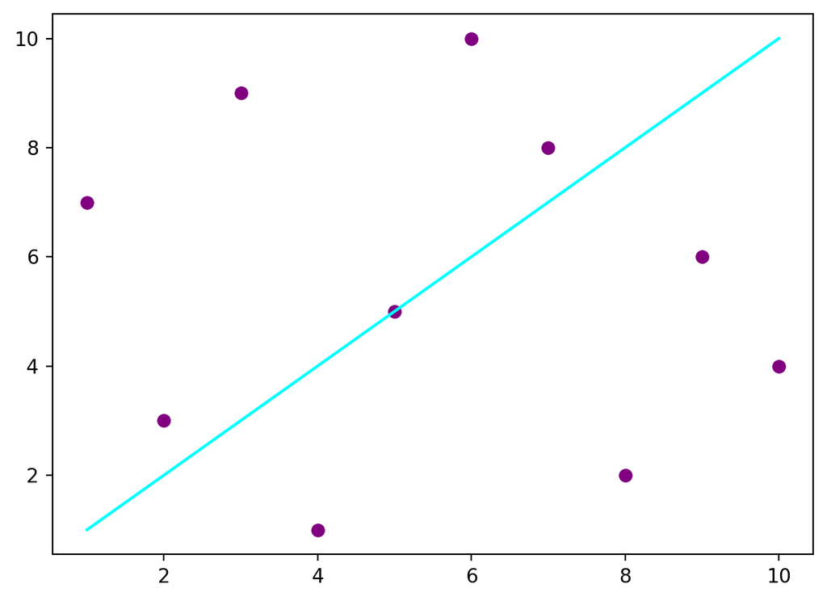

```python
import matplotlib.pyplot as plt # Import matplotlib

# Define some data
data1 = [1, 2, 3, 4, 5, 6, 7, 8, 9, 10]
data2 = [7, 3, 9, 1, 5, 10, 8, 2, 6, 4]

# Set the figure and the axes
fig, ax = plt.subplots()

# Plot the data
ax.plot(data1, data1, color='aqua', label='Line')
ax.scatter(data1, data2, color='purple', label='scatter')

# Customise the plot - up to you!
# - Add a title
# - Add x and y labels
# - Add a legend
# - Add a grid
```

### Plotting with Seaborn

Let’s now review the use of **Seaborn**. You might wonder why do we need another plotting library. Well, the topic of this module is data exploration, and this is exactly what *Seaborn* is designed for. In additions, *Seaborn* is designed to work with *Pandas*.

Over the next steps of the exercise we will use various types of plots offered by *Seaborn* to explore our geochemical dataset. Listing 4 illustrates how to create a [scatterplot](https://seaborn.pydata.org/generated/seaborn.scatterplot.html) of the Rubidium and Strontium values contained in our dataset `df`. *Seaborn* usually takes 4 arguments:

1. `ax`: The axes on which to plot the data
2. `data`: The DataFrame containing the data.
3. `x`: The name of the column containing the values used along x
4. `y`: The name of the column containing the values used along y

Listing 4: Basic plotting using Seaborn.

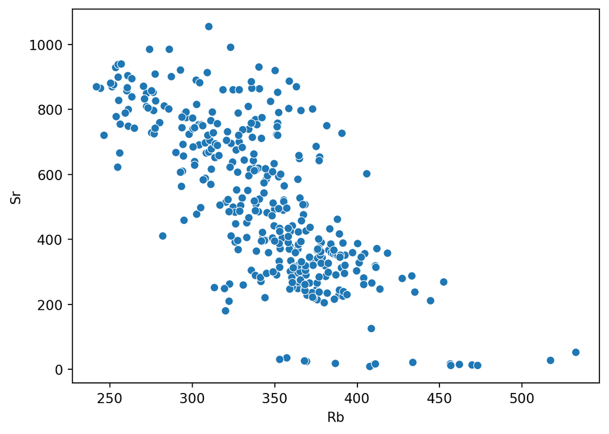

```python
# Define figure + axes
fig, ax = plt.subplots()
# Plot with seaborn (remember, we imported it as sns)
# df is the geochemical dataset imported previously
sns.scatterplot(ax=ax, data=df, x='Rb', y='Sr')
```

Should you feel adventurous and check out the [documentation](https://seaborn.pydata.org/generated/seaborn.scatterplot.html) of the `scatterplot` function, you would see that it is possible to use additional arguments to further customize the plot:

- `hue`: Name of the variable that will produce points with different colors.
- `size`: Name of the variable that will produce points with different sizes.

**Seaborn exercise**

Complete Listing 4, but use:

- The `"Epoch"` column to control points color.
- The `"SiO2* (EMP)"` column to control points size.

Remember, you can use `df.columns` to print a list of column names contained in the DataFrame.

## Descriptive statistics

### Univariate statistics

The objective of **descriptive statistics** is to provide ways of capturing the properties of a given data set or sample. Using *Pandas* and *Seaborn*, we will review some metrics, tools, and strategies that can be used to summarize a dataset, providing us with a quantitative basis to talk about it and compare it to other datasets.

By **univariate statistics**, we focus on capturing the properties of **single** variables at the time. We are not yet concerned in characterising the relationships between two or more variables.

Let’s focus on the Zircon concentration in Campi Flegrei’s geochemical dataset. Let’s start by simply visualising the dataset to get an understanding of what we will talk about. Figures below illustrate three different plot types:

1. **Histograms** ([`sns.histplots()`](https://seaborn.pydata.org/generated/seaborn.histplot.html)) show the number of times a specific Zr concentration occurs in our dataset (Listing 5).
2. **Box plots** ([`sns.boxplot()`](https://seaborn.pydata.org/generated/seaborn.boxplot.html) - or box-and-whisker plot) show the distribution of quantitative data with some measure of dispersion. Note that they are useful to compare between variables (Listing 6).
3. **Violin plots** ([`sns.violinplot()`](https://seaborn.pydata.org/generated/seaborn.violinplot.html)) are similar to box plots, but they approximate the underlying data distribution using some smoothing algorithm (i.e. *kernel density estimation*). Without going into too much detail, this provides a good first approximation of the distribution, but it can create some unrealistic artefacts (e.g., see the negative Sr concentrations in Listing 7).

**Histogram**

Listing 5: Visualising distributions using histograms.

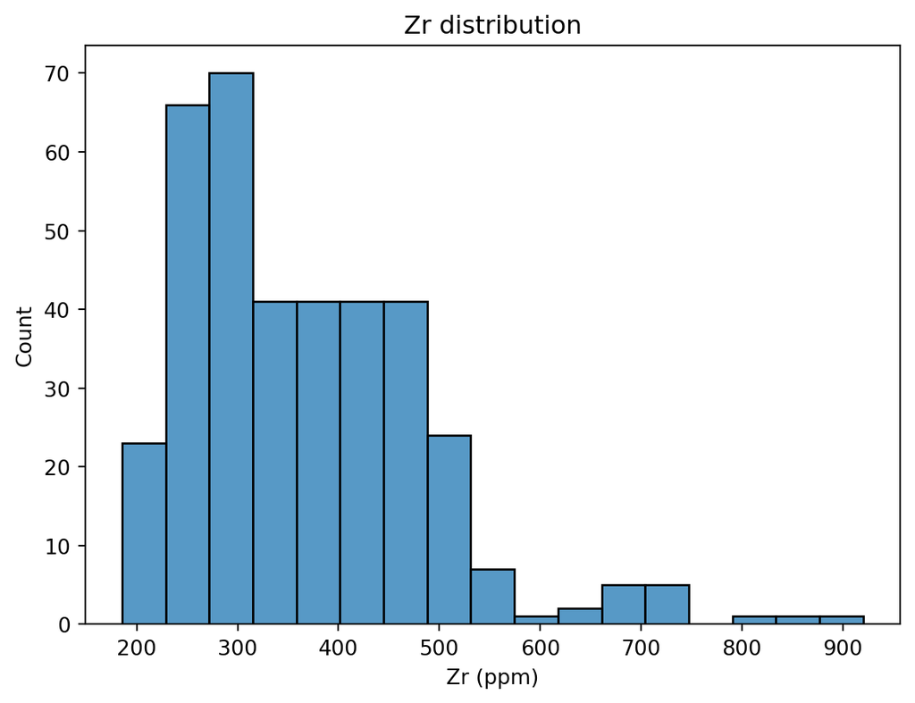

```python
fig, ax = plt.subplots()
sns.histplot(data=df, x='Zr')
ax.set_xlabel('Zr (ppm)');
ax.set_title('Zr distribution');
```

**Box plot**

**Plotting several columns**

Box plots are useful to plot and compare more than one data. Listing 6 slightly adjusts how `boxplot()` is called to allow for that.

Listing 6: Visualising distributions using box-and-whisker plots.

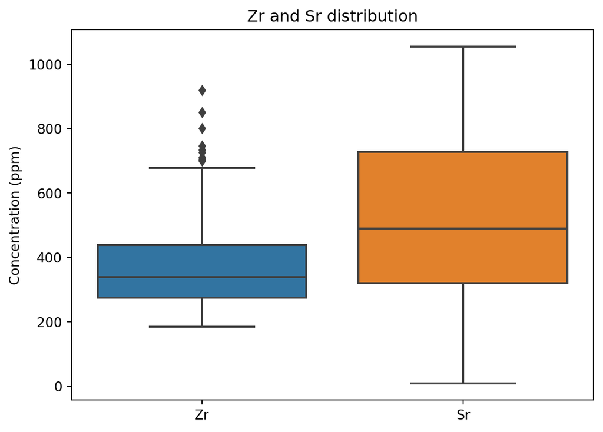

```python
fig, ax = plt.subplots()
sns.boxplot(data=df[['Zr', 'Sr']]) # We plot Zr and Sr together using a list
ax.set_ylabel('Concentration (ppm)');
ax.set_title('Zr and Sr distribution');
```

**Violin plot**

Listing 7: Visualising distributions using violin plots.

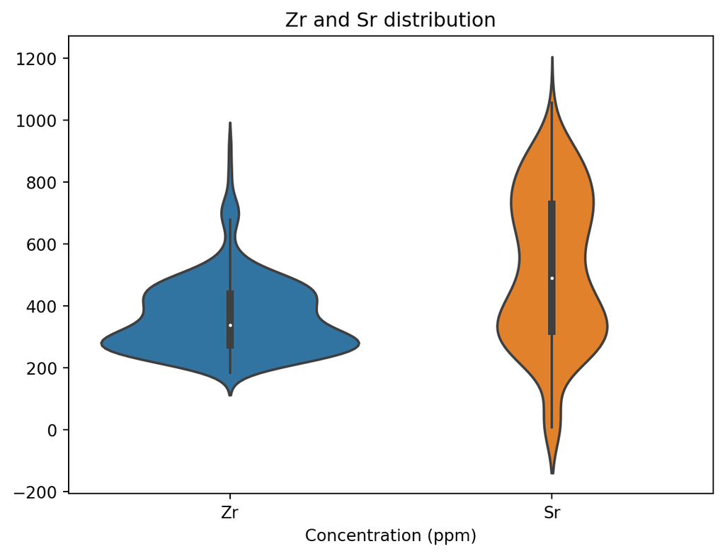

```python
fig, ax = plt.subplots()
sns.violinplot(data=df[['Zr', 'Sr']])
ax.set_xlabel('Concentration (ppm)');
ax.set_title('Zr and Sr distribution');
```

By looking at the Zr and St distributions from the figures above, we can intuitively understand the importance of describing three different parameters:

- The **location** - or where is the central value(s) of the dataset;
- The **dispersion** - or how spread out is the distribution of data compared to the central values;
- The **skewness** - or how symmetrical is the distribution of data compared to the central values;

#### Location

##### Mean

The **mean** (or *arithmetic* mean - by opposition to *geometric* or *harmonic* means) is the sum of the values divided by the number of values (Equation 1):

$$\bar{x} = \frac{1}{n} \sum_{i=1}^{n} x_i
\tag{1}$$

The mean is meaningful to describe **symmetric** distributions without **outliers**, where:

- **Symmetric** means the number of items above the mean should be roughly the same as the number below;
- **Outliers** are *extreme* values.

The mean of a dataset can easily be computed with *Pandas* using the [`.mean()`](https://pandas.pydata.org/docs/reference/api/pandas.DataFrame.mean.html) function (Listing 8). Note that we round the results to two significant digits using `.round(2)`.

Listing 8: Compute the mean for two significant digits.

```python
df['Zr'].mean().round(2)
```

```
365.38
```

**Question**

What is the mean value for Strontium?

**Descriptive stats functions**

Listing 8 shows how to compute the mean on one column, but the `.mean()` function - as well as most fuctions for descriptive stats - can be applied to entire DataFrames. For this, we need to understand a critical argument - `axis`.

- `axis = 0` is usually the default, and computes the mean across all rows for each column(Listing 9)
- `axis = 1` usually makes sense when rows are labelled, and computes the mean across all columns for each row(Listing 10)

Listing 9: Compute the mean across rows.

```python
# Create a subset of the df containing numerical data
df_sub = df[['Sc','Rb','Sr','Y','Zr','Nb','Cs']]
# Compute the mean across all rows
df_sub.mean(axis=0).round(2).head()
```

```
Sc      0.20
Rb    343.82
Sr    516.42
Y      31.33
Zr    365.38
dtype: float64
```

Listing 10: Compute the mean across columns.

```python
# Create a subset of the df containing numerical data
df_sub = df[['Sc','Rb','Sr','Y','Zr','Nb','Cs']]
# Compute the mean across all columns
df_sub.mean(axis=1).round(2).head()
```

```
0    198.32
1    188.41
2    188.48
3    200.69
4    198.42
dtype: float64
```

##### Median

The **median** is the value at the exact middle of the dataset, meaning that just as many elements lie above the median as below it. There is no easy formula to compute the median, instead we need to conceptually (Listing 11):

1. Order all values in ascending order and plot them against a normalised number of observations (this is called an empirical cumulative density function - or ECDF);
2. On the x-axis, find the point dividing the dataset into two equal numbers of observations;
3. Read the value on the y-axis that intersects the ECDF.

Listing 11: Graphical representation of the median.

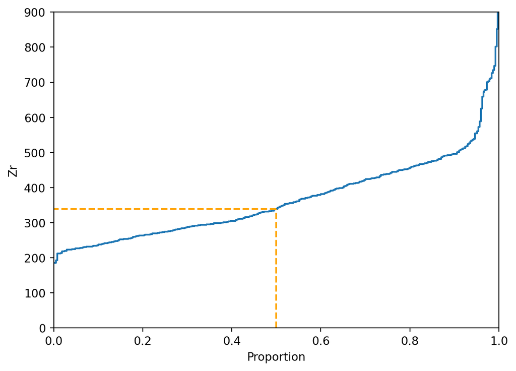

```python
fig, ax = plt.subplots()
sns.ecdfplot(data=df, y='Zr')
ax.plot([.5,.5], [0, df['Zr'].median()], color='orange', linestyle='--')
ax.plot([.5,0], [df['Zr'].median(), df['Zr'].median()], color='orange', linestyle='--')
ax.set_ylim([0,900])
```

Fortunately, we can also use the native *Pandas* [`.median`](https://pandas.pydata.org/docs/reference/api/pandas.DataFrame.median.html) function (Listing 12).

Listing 12: Compute the median for two significant digits.

```python
round(df['Zr'].median(), 2)
```

```
339.41
```

**Question**

What is the mean value for Cesium?

##### Summary

Listing 13 illustrate the values of the mean and the median relative to the distribution shown in the histogram. There are a few things to keep in mind when choosing between mean and median to estimate the location of a dataset:

- If a sample has a symmetrical distribution, then **the mean and median are equal**.
- If the distribution of a sample is not symmetrical, **the mean should not be used**.
- The mean is highly sensitive to outliers, whereas the median is not.

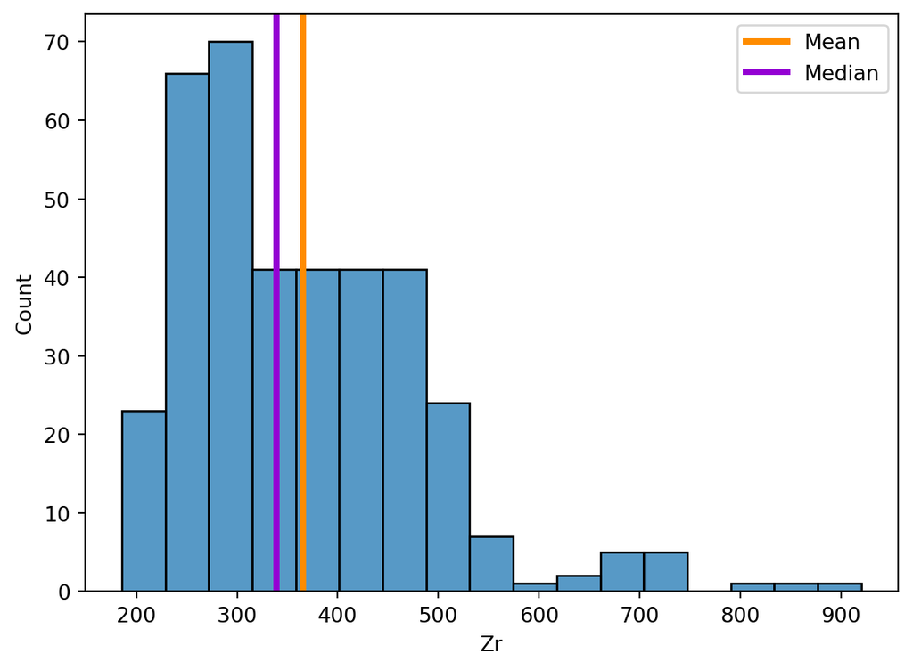

```python
fig, ax = plt.subplots()
sns.histplot(data=df, x='Zr')
ax.axvline(df['Zr'].mean(), color='darkorange', lw=3, label='Mean')
ax.axvline(df['Zr'].median(), color='darkviolet', lw=3, label='Median')
ax.legend()
```

#### Dispersion

##### Range

The first information we might want to get for a dataset is the range of values it covers, or *range*. For this, we need to get the minimum (`df.min()`) and maximum (`df.max()`) values, from which, when needed, the range can be calculated with Equation 2. It is however likely that the min/max functions will be more frequently used (Listing 14).

$$\text{Range} = \max(x) - \min(x)
\tag{2}$$

Listing 14: Compute the min and the max values of a column

```python
df['Zr'].min()
df['Zr'].max()
```

```
920.1744058431505
```

**Question**

What is the mean value for Cesium?

##### Variance and standard deviation

The **variance** and **standard deviation** are two key measures of dispersion that describe how spread out the values in a dataset are.

- **Standard deviation** ($\sigma$) measures sum of squares differences between data points $x_i$ and the mean $\bar{x}$:
  $$\sigma = \sqrt{\frac{\sum_{i=1}^{n} (x_i - \bar{x})^2}{n-1} }$$
  where $x_i$ are the data points, $\bar{x}$ is the mean, and $n$ is the number of observations.
- **Variance** ($\sigma^2$) is the square of the standard deviation:
  $$\sigma^2 = \frac{\sum_{i=1}^{n} (x_i - \bar{x})^2}{n-1}$$

For now we will consider that they roughly measure the same thing. The standard deviation is in the same units as the data, making it easier to interpret.

**Relation to the Gaussian distribution:**  
For a Gaussian (normal) distribution, about 68% of the data falls within one standard deviation of the mean, about 95% within two standard deviations, and about 99.7% within three standard deviations. Thus, variance and standard deviation are fundamental for describing the spread and probability intervals of normally distributed data.

#### Skewness x

### Bivariate statistics x

#### Correlation x

## Simple linear regression x

Petrelli, Maurizio. 2021. *Introduction to Python in Earth Science Data Analysis: From Descriptive Statistics to Machine Learning*. Springer Textbooks in Earth Sciences, Geography and Environment. Springer Cham. https://doi.org/10.1007/978-3-030-78055-5.

Smith, V. C., R. Isaia, and N. J. G. Pearce. 2011. “Tephrostratigraphy and Glass Compositions of Post-15 Kyr Campi Flegrei Eruptions: Implications for Eruption History and Chronostratigraphic Markers.” *Quaternary Science Reviews* 30 (25-26): 3638–60. https://doi.org/10.1016/j.quascirev.2011.07.012.